# WRI Oyster Pathogen Project

### Libraries

Analysis of output from MIrROR (see jupyter notebook for bioinformatics steps)

```r
library(tidyverse)
library(phyloseq)
library(microbiome)
library(vegan)
```

### Import MIrROR results

import the OTU table files- these have sample name in column name with abundance

```r
b01 <- read_delim(file = "results/b01/OTUtable/OUTPUT_std.txt", col_names = TRUE, delim = "\t", col_types = NULL)
b02 <- read_delim(file = "results/b02/OTUtable/OUTPUT_std.txt", col_names = TRUE, delim = "\t", col_types = NULL)
b03 <- read_delim(file = "results/b03/OTUtable/OUTPUT_std.txt", col_names = TRUE, delim = "\t", col_types = NULL)
b04 <- read_delim(file = "results/b04/OTUtable/OUTPUT_std.txt", col_names = TRUE, delim = "\t", col_types = NULL)
b05 <- read_delim(file = "results/b05/OTUtable/OUTPUT_std.txt", col_names = TRUE, delim = "\t", col_types = NULL)
b06 <- read_delim(file = "results/b06/OTUtable/OUTPUT_std.txt", col_names = TRUE, delim = "\t", col_types = NULL)
b07 <- read_delim(file = "results/b07/OTUtable/OUTPUT_std.txt", col_names = TRUE, delim = "\t", col_types = NULL)
b08 <- read_delim(file = "results/b08/OTUtable/OUTPUT_std.txt", col_names = TRUE, delim = "\t", col_types = NULL)
b09 <- read_delim(file = "results/b09/OTUtable/OUTPUT_std.txt", col_names = TRUE, delim = "\t", col_types = NULL)
b10 <- read_delim(file = "results/b10/OTUtable/OUTPUT_std.txt", col_names = TRUE, delim = "\t", col_types = NULL)
b11 <- read_delim(file = "results/b11/OTUtable/OUTPUT_std.txt", col_names = TRUE, delim = "\t", col_types = NULL)
b12 <- read_delim(file = "results/b12/OTUtable/OUTPUT_std.txt", col_names = TRUE, delim = "\t", col_types = NULL)
# b01 <- read_delim(file = "results/b01/OTUtable/OUTPUT_std.txt", col_names = TRUE, delim = "\t ")
# b02 <- read_delim(file = "results/b02/OTUtable/OUTPUT_std.txt", col_names = TRUE, delim = "\t ")
# b03 <- read_delim(file = "results/b03/OTUtable/OUTPUT_std.txt", col_names = TRUE, delim = "\t ")
# b04 <- read_delim(file = "results/b04/OTUtable/OUTPUT_std.txt", col_names = TRUE, delim = "\t ")
# b05 <- read_delim(file = "results/b05/OTUtable/OUTPUT_std.txt", col_names = TRUE, delim = "\t ")
# b06 <- read_delim(file = "results/b06/OTUtable/OUTPUT_std.txt", col_names = TRUE, delim = "\t ")
# b07 <- read_delim(file = "results/b07/OTUtable/OUTPUT_std.txt", col_names = TRUE, delim = "\t ")
# b08 <- read_delim(file = "results/b08/OTUtable/OUTPUT_std.txt", col_names = TRUE, delim = "\t ")
# b09 <- read_delim(file = "results/b09/OTUtable/OUTPUT_std.txt", col_names = TRUE, delim = "\t ")
# b10 <- read_delim(file = "results/b10/OTUtable/OUTPUT_std.txt", col_names = TRUE, delim = "\t ")
# b11 <- read_delim(file = "results/b11/OTUtable/OUTPUT_std.txt", col_names = TRUE, delim = "\t ")
# b12 <- read_delim(file = "results/b12/OTUtable/OUTPUT_std.txt", col_names = TRUE, delim = "\t ")
```

### Make tables

join all samples into one variable, `otutable`

```r
otutable <- full_join(x = b01, y = b02, by = "#Name")
otutable <- full_join(x = otutable, y = b03, by = "#Name")
otutable <- full_join(x = otutable, y = b04, by = "#Name")
otutable <- full_join(x = otutable, y = b05, by = "#Name")
otutable <- full_join(x = otutable, y = b06, by = "#Name")
otutable <- full_join(x = otutable, y = b07, by = "#Name")
otutable <- full_join(x = otutable, y = b08, by = "#Name")
otutable <- full_join(x = otutable, y = b09, by = "#Name")
otutable <- full_join(x = otutable, y = b10, by = "#Name")
otutable <- full_join(x = otutable, y = b11, by = "#Name")
otutable <- full_join(x = otutable, y = b12, by = "#Name")
```

modify column names from “b01.fa” to just “b01” etc

```r
colnames(otutable) <- c("Name","b01","b02","b03","b04","b05","b06","b07","b08","b09","b10","b11","b12")
```

export to txt file

```r
# dir.create("results2")
write_delim(x = otutable, file = "results2/otutable.txt")
```

reformat so can be loaded into phyloseq

```r
otutable[is.na(otutable)] <- 0
otumat <- as.matrix(otutable[,2:ncol(otutable)])
rownames(otumat) <- paste0("OTU",1:nrow(otumat))
head(otumat)
```

```
     b01 b02 b03 b04 b05  b06 b07 b08 b09 b10 b11 b12
OTU1   1   2   0   0   0 1251   0   1   0   0   3   0
OTU2   1 301   0   4   3 6124   0   4   0   5  10   0
OTU3   5   0   1   2   0    2 488   0   0   0   2   0
OTU4   1   0   0   0   0    0   0   0   0   0   0   0
OTU5  45   0   0   0   1    0   0   0   0   0   0   0
OTU6 169   0   0   0   0    0   0   0   0   0   1   0
```

```r
taxmat <- otutable[,1] %>% mutate(Name = str_remove_all(Name, pattern = ".__"))
taxmat <- taxmat %>%
  separate(Name, sep = (";"), c("Phylum", "Class","Order","Family","Genus","Species"))
rownames(taxmat) <- paste0("OTU",1:nrow(otumat))
taxmat <- as.matrix(taxmat)
head(taxmat)
```

```
     Phylum             Class            Order             Family               Genus
OTU1 "Actinobacteriota" "Acidimicrobiia" "Microtrichales"  "Ilumatobacteraceae" "Ilumatobacter"
OTU2 "Actinobacteriota" "Acidimicrobiia" "Microtrichales"  "Ilumatobacteraceae" "Ilumatobacter"
OTU3 "Actinobacteriota" "Actinobacteria" "Actinomycetales" "Actinomycetaceae"   "Actinomyces"
OTU4 "Actinobacteriota" "Actinobacteria" "Actinomycetales" "Actinomycetaceae"   "Pauljensenia"
OTU5 "Actinobacteriota" "Actinobacteria" "Actinomycetales" "Actinomycetaceae"   "Pauljensenia"
OTU6 "Actinobacteriota" "Actinobacteria" "Actinomycetales" "Actinomycetaceae"   "Pauljensenia"
     Species
OTU1 "Ilumatobacter_coccineus"
OTU2 "Ilumatobacter_nonamiensis"
OTU3 "Actinomyces_oris"
OTU4 "Pauljensenia_cellulosilytica"
OTU5 "Pauljensenia_odontolyticus"
OTU6 "Pauljensenia_pacaensis"
```

Combine into phyloseq object

```r
OTU <- otu_table(otumat, taxa_are_rows = TRUE)
TAX <- tax_table(taxmat)
ps <- phyloseq(OTU, TAX)
ps
```

```
phyloseq-class experiment-level object
otu_table()   OTU Table:         [ 1731 taxa and 12 samples ]
tax_table()   Taxonomy Table:    [ 1731 taxa by 6 taxonomic ranks ]
```

### Plot phyla

Test some plots

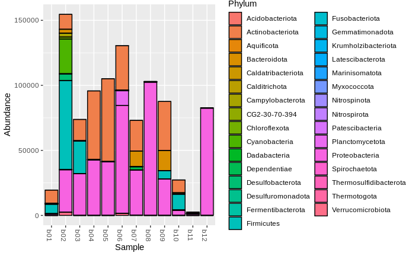

```r
ps_phyla <- tax_glom(ps, "Phylum")
phylacountsplot <- plot_bar(ps_phyla, fill = "Phylum")
phylacountsplot

ggsave(plot = phylacountsplot, filename = "results2/phylacountsplot.png")
```

These are on the order of magnitude of reads I get with Illumina data so that’s great. Sample B11 is the negative control- low # of hits makes sense. B1 and B10 are same oyster- diversity looks the same. Great.

make rel abun table

```r
# convert to rel abun ("compositional")
ps_compositional <-
  microbiome::transform(ps, transform = "compositional")
```

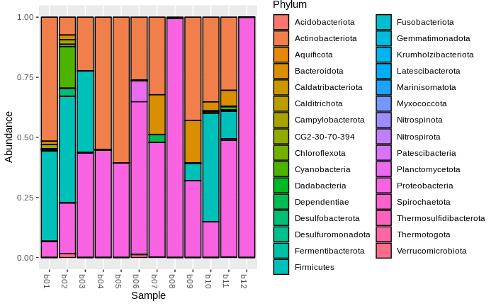

```r
ps_compositional_phyla <- tax_glom(ps_compositional, "Phylum")
phylumplot <- plot_bar(ps_compositional_phyla, fill = "Phylum")
phylumplot
ggsave(plot = phylumplot, filename = "results2/phylumplot.png")
```

### Check rarefaction

```r
tab <- otu_table(ps)
class(tab) <- "matrix"
rarecurve(t(tab), step=50, cex=0.5)

# export
png(file="results2/rarefaction.png")
```

[figure not shown]

```r
rarecurve(t(tab), step=50, cex=0.5)
dev.off()
```

### Check diversity

```r
shannons <- tibble(Div = diversity(x = t(otumat), index = "shannon"), samples = colnames(otumat))
shannons
```

| Div | samples |
| --- | --- |
| 3.100707307 | b01 |
| 4.392707373 | b02 |
| 1.783849075 | b03 |
| 0.999685609 | b04 |
| 0.715577400 | b05 |
| 2.778924022 | b06 |
| 2.878283015 | b07 |
| 0.065897297 | b08 |
| 2.320976787 | b09 |
| 3.443623989 | b10 |

[output cut: 2 more lines]

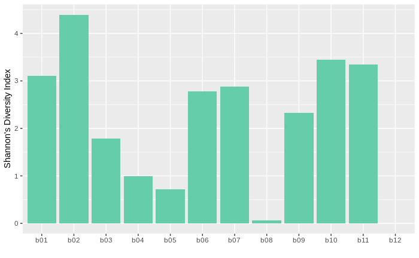

```r
shannonplot <- ggplot(shannons) +
  geom_col(aes(y = as.numeric(Div), x = samples), fill = "aquamarine3") +
  ylab("Shannon's Diversity Index") + xlab("")
shannonplot

ggsave(plot = shannonplot, filename = "results2/shannonsplot.png")
```

### Some sequencing statistics

```r
# total reads annotated
sum(otutable[,2:length(otutable)])
```

```
[1] 955323
```

```r
# No. of unique species in whole dataset
dim(otutable)[1]
```

```
[1] 1731
```

```r
# total reads per species, across all samples
otutable %>%
  mutate(sum = rowSums(across(where(is.numeric))))
```

| Name | b01 | b02 | b03 | b04 | b05 | b06 | b07 | b08 | b09 | b10 | b11 | b12 | sum |
| --- | --- | --- | --- | --- | --- | --- | --- | --- | --- | --- | --- | --- | --- |
| p__Actinobacteriota;c__Acidimicrobiia;o__Microtrichales;f__Ilumatobacteraceae;g__Ilumatobacter;s__Ilumatobacter_coccineus | 1 | 2 | 0 | 0 | 0 | 1251 | 0 | 1 | 0 | 0 | 3 | 0 | 1258 |
| p__Actinobacteriota;c__Acidimicrobiia;o__Microtrichales;f__Ilumatobacteraceae;g__Ilumatobacter;s__Ilumatobacter_nonamiensis | 1 | 301 | 0 | 4 | 3 | 6124 | 0 | 4 | 0 | 5 | 10 | 0 | 6452 |
| p__Actinobacteriota;c__Actinobacteria;o__Actinomycetales;f__Actinomycetaceae;g__Actinomyces;s__Actinomyces_oris | 5 | 0 | 1 | 2 | 0 | 2 | 488 | 0 | 0 | 0 | 2 | 0 | 500 |
| p__Actinobacteriota;c__Actinobacteria;o__Actinomycetales;f__Actinomycetaceae;g__Pauljensenia;s__Pauljensenia_cellulosilytica | 1 | 0 | 0 | 0 | 0 | 0 | 0 | 0 | 0 | 0 | 0 | 0 | 1 |
| p__Actinobacteriota;c__Actinobacteria;o__Actinomycetales;f__Actinomycetaceae;g__Pauljensenia;s__Pauljensenia_odontolyticus | 45 | 0 | 0 | 0 | 1 | 0 | 0 | 0 | 0 | 0 | 0 | 0 | 46 |
| p__Actinobacteriota;c__Actinobacteria;o__Actinomycetales;f__Actinomycetaceae;g__Pauljensenia;s__Pauljensenia_pacaensis | 169 | 0 | 0 | 0 | 0 | 0 | 0 | 0 | 0 | 0 | 1 | 0 | 170 |
| p__Actinobacteriota;c__Actinobacteria;o__Actinomycetales;f__Actinomycetaceae;g__Pauljensenia;s__Pauljensenia_sp000411415 | 1 | 0 | 0 | 0 | 0 | 0 | 0 | 0 | 0 | 0 | 0 | 0 | 1 |
| p__Actinobacteriota;c__Actinobacteria;o__Actinomycetales;f__Micrococcaceae;g__Kocuria;s__Kocuria_rhizophila | 192 | 498 | 1 | 0 | 1 | 0 | 0 | 0 | 0 | 0 | 0 | 0 | 692 |
| p__Actinobacteriota;c__Actinobacteria;o__Actinomycetales;f__Micrococcaceae;g__Renibacterium;s__Renibacterium_salmoninarum | 64 | 0 | 0 | 0 | 0 | 0 | 0 | 0 | 0 | 0 | 0 | 0 | 64 |
| p__Actinobacteriota;c__Actinobacteria;o__Actinomycetales;f__Micrococcaceae;g__Rothia;s__Rothia_aeria | 137 | 0 | 0 | 1 | 0 | 0 | 0 | 2 | 0 | 1078 | 4 | 0 | 1222 |

[output cut: 990 more lines]

```r
# total reads per sample
otutable %>%
  summarise(across(where(is.numeric),sum))
```

| b01 | b02 | b03 | b04 | b05 | b06 | b07 | b08 | b09 | b10 | b11 | b12 |
| --- | --- | --- | --- | --- | --- | --- | --- | --- | --- | --- | --- |
| 19504 | 154581 | 73808 | 95717 | 105113 | 130486 | 73063 | 102995 | 87592 | 27285 | 2609 | 82570 |

```r
NA
```

### To Do

- remove contamination
- pull out most abundance spp from each sample and, for potential pathogens, calculate % age of total community

### Questions to resolve

How many reads were not annotated?  
Confidence in alignment and annotation?  
- [minimapper2 documentation](https://lh3.github.io/minimap2/minimap2.html) - [MIRrROR repo](https://github.com/seoldh/MIrROR) -